# Homophily and Monophily of Internet Industry Partnerships

Yu Huang

12/10/2021

## Introduction

Altenburger and Ugander (2018) introduced the concept of “monophily” in their paper to represent the phenomenon of individuals with extreme preferences for a particular attribute that is possibly unrelated with their own attribute. As a result, friends-of-friends are more likely to be similar. While “homophily” focuses on a bias in attribute preferences for similar others, “monophily” considers the excess variance/overdispersion in attribute preferences. They define this excess variance as observing more variance than expected under a statistical model of interaction preferences with homophily as a bias parameter. Built on this base model, an additional parameter $\phi$ was introduced to account for the extra variance. The extended model can simultaneously characterize homophily and monophily observed in a network. They investigated 4 different empirical social networks where monophily might be present – gender in FB100 networks (Traud et al., 2012) and Add Health networks (Resnick et al., 1997), which may exhibit weak homophily, and political affiliations of online blogs (Adamic & Glance, 2005) and contact network of terrorist group members and non-members in the Noordin Top Terrorist Network (Roberts & Everton, 2011), which are known to be highly homophilous. They applied 4 node classification methods to predict node attribute in each of the four networks. 2 classification methods, the one-hop MV classifier and the ZGL method, are based on a node’s one-hop (immediate) relations, so homophily in the networks is key to classification performance. The other 2 methods, the two-hop MV classifier and the LINK-logistic regression, capitalize on two-hop (neighbor of neighbor) relations, where monophily in the networks could contribute to prediction of node attributes. They showed that the two-hop methods (two-hop MV and LINK) performed consistently better than one-hop ones in predicting gender on Facebook networks, and as well as the other methods in predicting political affiliation. Here, I apply their statistical model to a network involving company partnerships in the internet industry to estimate its homophily and monophily parameters. Then, I perform node classification of company type using the 4 classification methods and compare the relative performance of one-hop and two-hop methods.

## Methods

### Data

The data set I used was collected from [link](https://networkrepository.com/). It contains a partnership network of 219 companies, which is a subset of 250 companies in the internet industry during the period from 1998 to 2001. In the network, each node represents a company that competes in the internet industry. Besides, each node has an attribute associated with it, showing the company’s type, and has one of the three possible values: 1 for content, 2 for infrastructure, and 3 for commerce. There is an edge between two companies if they have announced a joint venture, strategic alliance or other types of partnership.

install and load packages

load internet-industry-partnerships data

```r
setwd("E:/work&study/study/PhD/Psych 496/project/data/internet-industry-partnerships")
net_partners_edges = read.table("internet-industry-partnerships_edges.txt", sep = ",", header = FALSE)
net_partners_node_labels = read.table("internet-industry-partnerships_node_labels.txt", header = FALSE)
```

create graph from data and preprocess

```r
net_partners_edges = as.matrix(net_partners_edges)
net_partners = graph_from_edgelist(net_partners_edges, directed = FALSE)
net_partners_adj_mat = as_adjacency_matrix(net_partners, type = "both", sparse = FALSE)

net_partners = asNetwork(net_partners)
set.vertex.attribute(net_partners, "type", value = net_partners_node_labels$V1)
get.vertex.attribute(net_partners, "type")
```

```
##   [1] 1 2 2 1 2 2 3 3 3 2 2 1 3 3 3 1 3 2 1 2 2 2 1 2 1 1 2 2 1 3 3 2 2 2 2 2 1
##  [38] 3 1 3 2 1 3 1 1 2 2 2 2 2 2 3 3 3 1 1 2 2 2 2 1 2 2 2 3 2 1 1 3 1 3 3 3 2
##  [75] 3 2 3 1 2 2 2 1 2 2 2 2 2 2 2 2 1 2 2 3 2 2 2 2 2 2 2 2 2 2 2 2 2 2 2 2 2
## [112] 3 3 2 2 2 2 2 1 2 2 3 2 2 2 2 2 3 1 2 2 2 3 2 3 2 2 2 3 2 2 2 1 2 2 1 2 2
## [149] 2 2 2 2 2 2 2 2 1 2 2 1 1 2 2 2 2 2 2 2 2 2 2 3 3 3 2 1 2 2 2 1 3 3 3 2 2
## [186] 1 1 1 1 1 2 2 1 2 2 1 2 3 2 2 2 2 1 3 3 2 2 3 2 2 1 3 3 2 2 3 1 2 3
```

```r
components(net_partners)  # there is only 1 component in this dataset
```

```
## [1] 1
```

```r
sum(degree(net_partners) == 0) # no 0-degree nodes
```

```
## [1] 0
```

```r
#remove nodes w/o label
sum(get.vertex.attribute(net_partners, "type")==0)  # all nodes have labels
```

```
## [1] 0
```

```r
#create a label vector
net_type = get.vertex.attribute(net_partners,"type")
```

### Network visualization

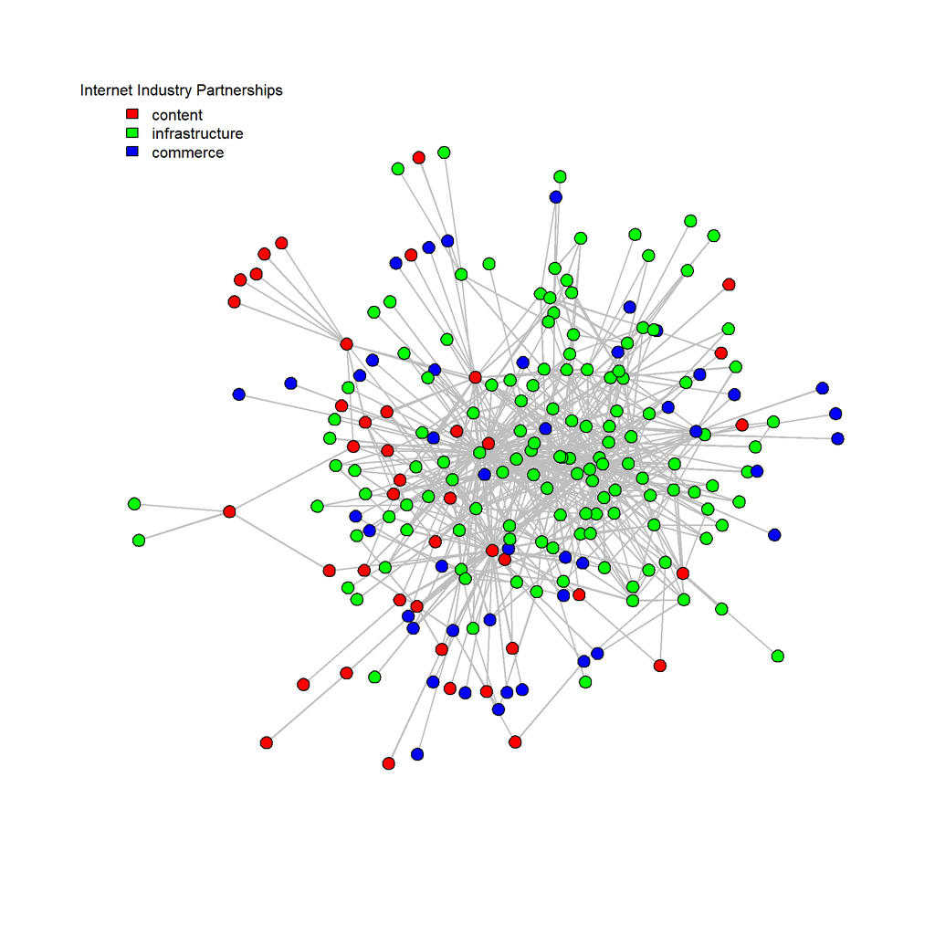

```r
node_cols = c("red", "green", "blue")
{gplot(net_partners, vertex.col = node_cols[net_type], edge.col = "gray", gmode = "graph")
par(margin(t=1, r=2, b=1, l=1))
legend(x="topleft", bty = "n",
       legend = c("content","infrastructure", "commerce"),
       fill = node_cols,
       title = "Internet Industry Partnerships")}
```

### Histogram of in-class preference for each type

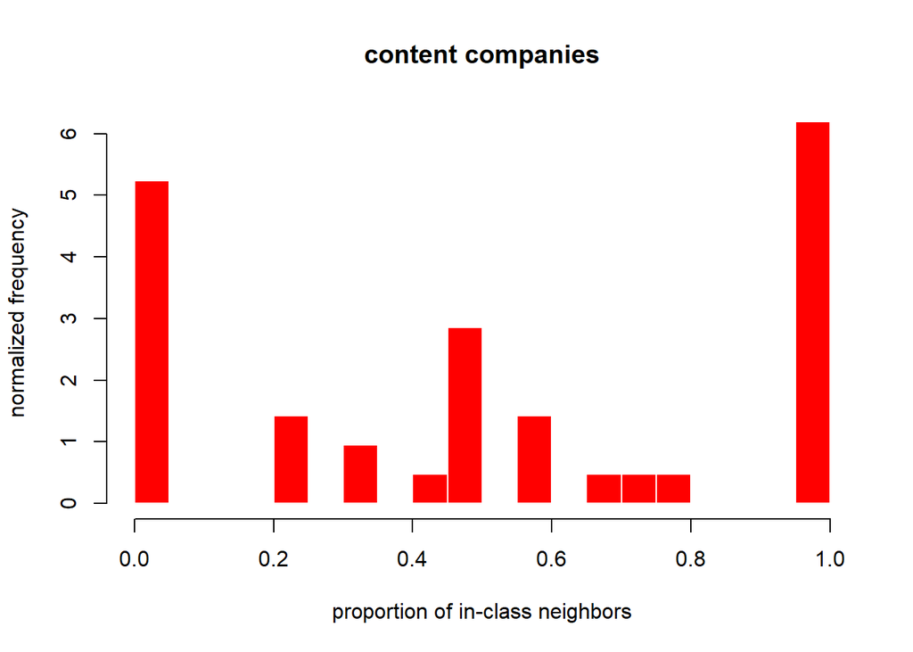

```r
net_content_label = 1
net_infra_label = 2
net_commerce_label = 3

#content
content_nodes = get.vertex.attribute(net_partners, "type") == net_content_label
in_content_degree = net_partners_adj_mat[content_nodes,] %*% matrix(as.numeric(net_type == net_content_label))
in_content_degree = as.matrix(in_content_degree)
total_content_degree = degree(net_partners, nodes = which(net_partners%v%"type"==net_content_label), gmode="graph")
h_content = sum(in_content_degree) / sum(total_content_degree)  #homophily index for content

hist(in_content_degree/total_content_degree, freq = FALSE, breaks = 25,
     col = 'red', border = "white",
     xlab = "proportion of in-class neighbors",
     ylab = "normalized frequency", main = "content companies")
```

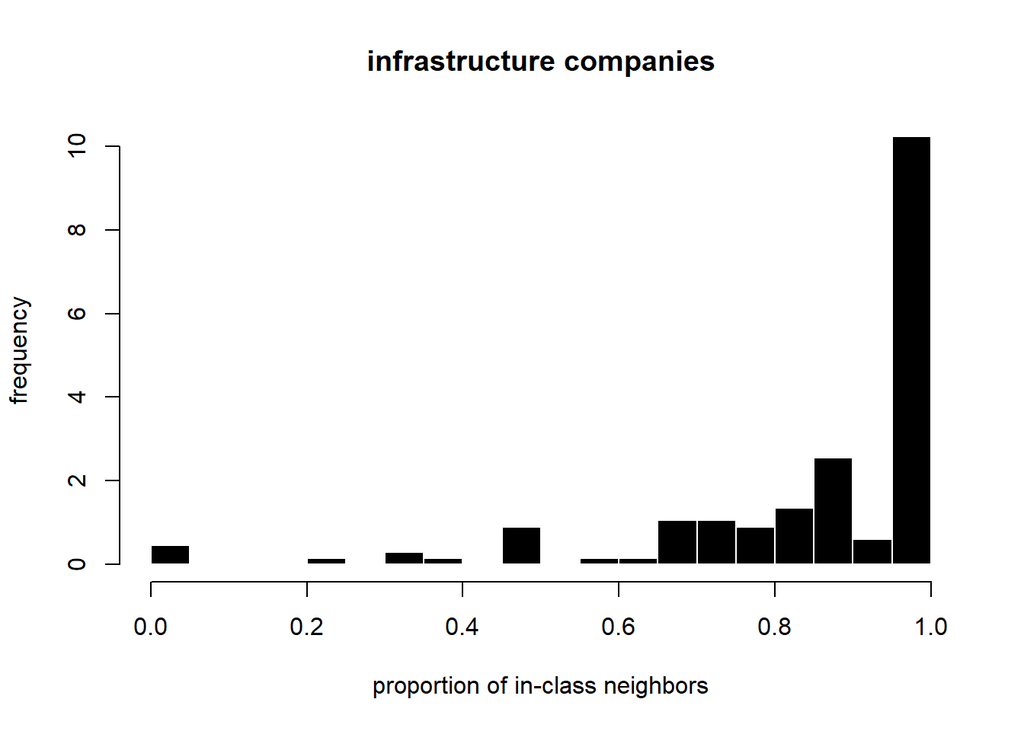

```r
#infrastructure
infra_nodes = get.vertex.attribute(net_partners, "type") == net_infra_label
in_infra_degree = net_partners_adj_mat[infra_nodes,] %*% matrix(as.numeric(net_type == net_infra_label))
in_infra_degree = as.matrix(in_infra_degree)
total_infra_degree = degree(net_partners, nodes = which(net_partners%v%"type"==net_infra_label), gmode="graph")
h_infra = sum(in_infra_degree) / sum(total_infra_degree)  #homophily index for infrastructure

hist(in_infra_degree/total_infra_degree, freq = FALSE,
     breaks = 25, col = 'black', border = "white",
     xlab = "proportion of in-class neighbors", ylab = "frequency", main = "infrastructure companies")
```

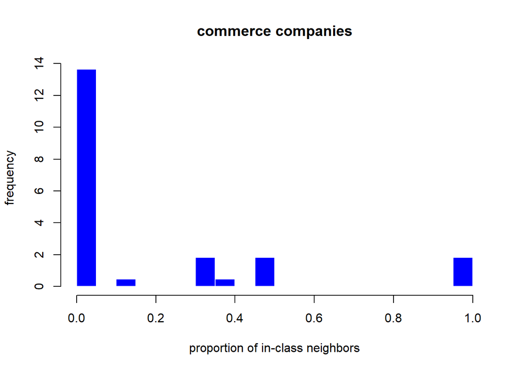

```r
##commerce
commerce_nodes = get.vertex.attribute(net_partners,"type") == net_commerce_label
in_commerce_degree = net_partners_adj_mat[commerce_nodes,] %*% matrix(as.numeric(net_type == net_commerce_label))
in_commerce_degree = as.matrix(in_commerce_degree)
total_commerce_degree = degree(net_partners, nodes = which(net_partners%v%"type"==net_commerce_label), gmode="graph")
h_commerce = sum(in_commerce_degree) / sum(total_commerce_degree)  #homophily index for commerce

hist(in_commerce_degree/total_commerce_degree, freq = FALSE,
     breaks = 25, col = 'blue', border = "white",
     xlab = "proportion of in-class neighbors", ylab = "frequency", main = "commerce companies")
```

Different company types have different patterns of preference for in-class partnerships. Infrastructure companies tend to become partner with other infrastructure companies, whereas commerce companies tend to partner with non-commerce companies. Content companies have two extremes - some prefer to partner with other content counterparts, while some prefer to partner with non-content companies.

### Comparison of empirical distribution (filled bars) with a simulated null distribution (solid lines) of in-class preference, for each type

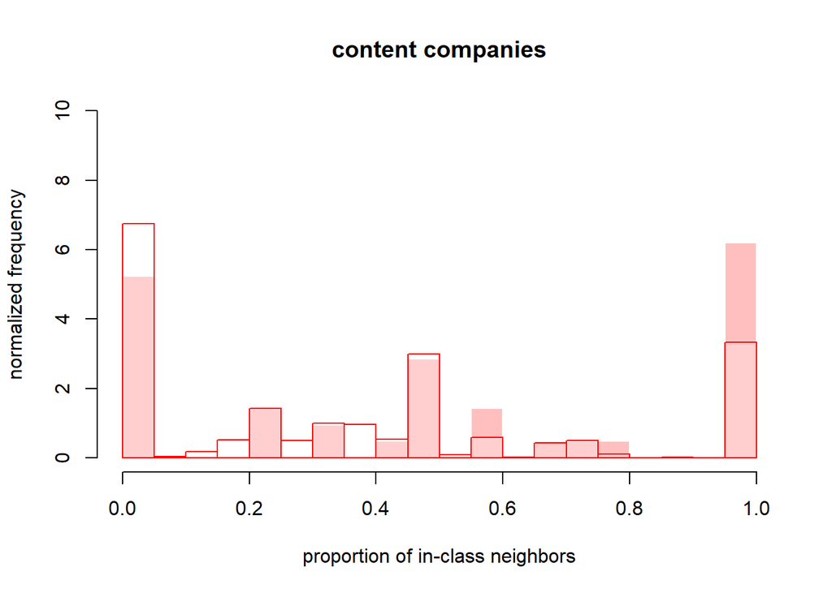

```r
set.seed(42)
n_iter = 100000

#content
mc_content = matrix(nrow = n_iter, ncol = length(total_content_degree))
for (i in 1:length(total_content_degree)){
  mc_content[,i] = rbinom(n=n_iter, size=total_content_degree[i], prob = h_content) / total_content_degree[i]
}
mc_content_final = as.vector(mc_content)

#compare w/ empirical dist
try({hist(in_content_degree/total_content_degree, freq = 0, breaks = 25,
     col = adjustcolor("red", alpha.f = 0.25), border = "white",
     ylim = c(0,10),
     xlab = "proportion of in-class neighbors",
     ylab = "normalized frequency", main = "content companies")+
hist(mc_content_final, breaks = 25, freq = 0,
     col = adjustcolor("white",alpha.f = 0.25), border = "red",
     add=TRUE)}, silent = TRUE)
```

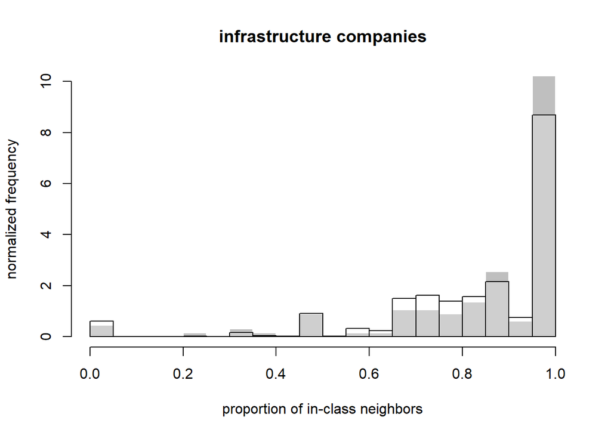

```r
#infra
mc_infra = matrix(nrow = n_iter, ncol = length(total_infra_degree))
for (i in 1:length(total_infra_degree)){
  mc_infra[,i] = rbinom(n=n_iter, size=total_infra_degree[i], prob = h_infra) / total_infra_degree[i]
}
mc_infra_final = as.vector(mc_infra)

#compare w/ empirical dist
try({hist(in_infra_degree/total_infra_degree, freq = FALSE, breaks = 25,
     col = adjustcolor("black", alpha.f = 0.25), border = "white",
     ylim = c(0,10),
     xlab = "proportion of in-class neighbors",
     ylab = "normalized frequency", main = "infrastructure companies") +
  hist(mc_infra_final, breaks = 25, freq = FALSE,
     col = adjustcolor("white", alpha.f = 0.25), border = "black",
     add=TRUE)
}, silent = TRUE)
```

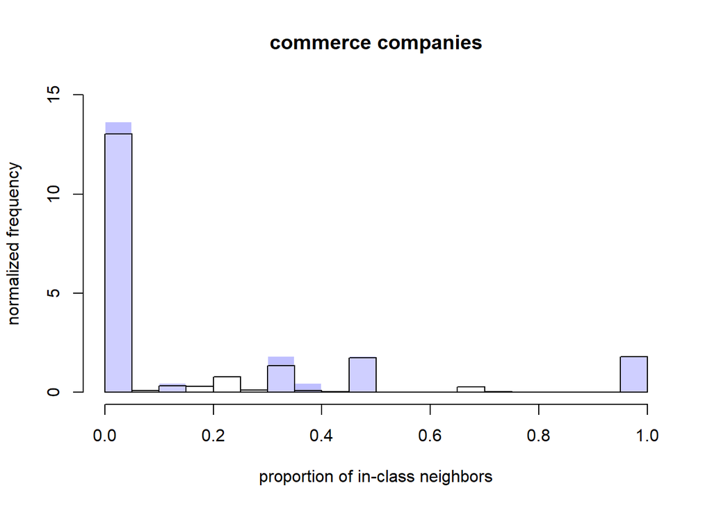

```r
##commerce
mc_commerce = matrix(nrow = n_iter, ncol = length(total_commerce_degree))
for (i in 1:length(total_commerce_degree)){
  mc_commerce[,i] = rbinom(n=n_iter, size=total_commerce_degree[i], prob = h_commerce) / total_commerce_degree[i]
}
mc_commerce_final = as.vector(mc_commerce)

#compare w/ empirical dist
try({hist(in_commerce_degree/total_commerce_degree, freq = FALSE, breaks = 25,
     col = adjustcolor("blue", alpha.f = 0.25), border = "white",
     ylim = c(0,15),
     xlab = "proportion of in-class neighbors",
     ylab = "normalized frequency", main = "commerce companies") +
  hist(mc_commerce_final, breaks = 25, freq = FALSE,
     col = adjustcolor("white", alpha.f = 0.25), border = "black",
     add=TRUE)
}, silent = TRUE)
```

For each company type, especially infrastructure and content, the empirical distribution (filled bars) of preferences for within-type partnerships are more dispersed (less concentrated) than the simulated, homophily-only null distribution (solid lines) (see **Appendix** for details).

### Homophily index and p value for each type

```r
compute_homophily_pvalue = function(deg_same, deg_different){
    mod <- glm(cbind(deg_same, deg_different) ~ 1, family=binomial(logit))
    return(coef(summary(mod))[,4])
}

num_labels = length(unique(get.vertex.attribute(net_partners,"type")))
class_labels = sort(unique(get.vertex.attribute(net_partners,"type")))

homophily_index_by_class = matrix(nrow=1, ncol=num_labels)
homophily_pvalue_by_class = matrix(nrow=1, ncol=num_labels)

for (j in 1:num_labels){
  ## among companies of type 'j' -- find # of their partners also of type 'j'
  same_j = net_partners_adj_mat[get.vertex.attribute(net_partners,"type")==class_labels[j],]  %*% matrix(as.numeric(get.vertex.attribute(net_partners,"type") == class_labels[j]))
   ## among companies of type 'j' -- find # of their partners not of type 'j'
  different_j = net_partners_adj_mat[get.vertex.attribute(net_partners,"type")==class_labels[j],] %*% matrix(as.numeric(get.vertex.attribute(net_partners, "type") != class_labels[j]))

  r_same = as.matrix(same_j)
  r_different = as.matrix(different_j)

  homophily_index_by_class[j] = sum(r_same)/sum(r_same + r_different)
  homophily_pvalue_by_class[j] = compute_homophily_pvalue(r_same, r_different)
}


homophily_index_by_class
```

```
##           [,1]      [,2]      [,3]
## [1,] 0.3781095 0.8373557 0.1851852
```

```r
homophily_pvalue_by_class
```

```
##             [,1]         [,2]         [,3]
## [1,] 0.000624384 8.869632e-78 2.217026e-09
```

Each type has a homophily index with significant a p-value. Infrastructure companies have the highest homophily index value (0.837), content companies the second (0.378), and commerce companies have the lowest (0.185).

To account for the extra variation of in-class preferences, as demonstrated by the comparisons of empirical distributions with homophily-only null distributions above, they extend the model to include another parameter, $\phi$, the monophily index, into the model (see **Appendix** for details). Below, I compute the monophily index for each class.

### Monophily index for each type

```r
compute_overdispersion = function(deg_same, deg_different){
  mod = glm(cbind(deg_same, deg_different) ~ 1, family = binomial(logit))
  mod.disp = glm.binomial.disp(mod, maxit=50, verbose=FALSE)
  mod.disp$dispersion
}

monophily_index_by_class = matrix(nrow=1, ncol=num_labels)

for (j in 1:num_labels){
  ## among companies of type 'j' -- find # of their partners also of type 'j'
  same_j = net_partners_adj_mat[get.vertex.attribute(net_partners,"type")==class_labels[j],]  %*% matrix(as.numeric(get.vertex.attribute(net_partners,"type") == class_labels[j]))
   ## among companies of type 'j' -- find # of their partners not of type 'j'
  different_j = net_partners_adj_mat[get.vertex.attribute(net_partners,"type")==class_labels[j],] %*% matrix(as.numeric(get.vertex.attribute(net_partners, "type") != class_labels[j]))

  r_same = as.matrix(same_j)
  r_different = as.matrix(different_j)

  monophily_index_by_class[j] = compute_overdispersion(r_same, r_different)
}

monophily_index_by_class
```

```
##           [,1]       [,2]        [,3]
## [1,] 0.2032232 0.06723594 0.005037071
```

Each company type has a monophily index greater than 0, indicating there is excess variation of within-type partnership preferences for each type. Content companies have a especially high value - evidence for great variance of in-class preference as illustrated in the figure.

To examine the effect of monophily on the performance of different inference methods for node attribute, they employed 4 classification models and categorized them based on the neighborhood relationships they can exploit for classification, either using 1-hop (neighbor) or two-hop (neighbor-of-neighbor) relations. The classifiers based on a node’s 1-hop relations are the 1-hop majority vote (1-hop MV) classifier (Macskassy & Provost, 2007) and the Zhu, Ghahramani and Lafferty (ZGL) method (Zhu et al., 2003). 1-hop MV capitalizes on similarities between connected nodes. ZGL can be viewed as an iterated/semi-supervised adaptation of 1-hop MV. The methods built on 2-hop relations are the 2-hop majority vote (MV) classifier and the LINK-logistic regression (Zheleva & Getoor, 2009). 2-hop MV builds on the relationship between a node and its 2-hop neighbors. LINK uses labeled nodes to fit a regularized logistic regression model by having rows of the adjacency matrix as binary feature vectors, performing classification based on these features.

Below, I perform the 4 classification methods on the Internet Industry Partnerships data set. I use the proportion of unlabeled nodes as the proportion of data used for the testing data set. By varying the proportion of unlabeled data, I am able to compare the prediction performance of each model in different situations - when training data set is large or small. Like the authors, I use the weighted AUC score as my evaluation measure. AUC (area under the curve) is a common measure for summarizing receiver operating characteristic (ROC) curves across a range of decision thresholds and is frequently used for evaluating classifier performance in networks. For each model and each proportion of unlabeled data, I run 100-fold cross-validation on the training data and use the mean of the weighted AUC scores as my final score.

### Comparison of 1-hop vs. 2-hop classifiers

#### 1-hop MV

Let’s try calling the model created in Python from R.

```python
percent_initially_unlabelled = [0.9,0.8,0.7,0.6,0.5,0.4,0.3,0.2,0.1]
percent_initially_labelled = np.subtract(1, percent_initially_unlabelled)

mean_wt_auc_mv_net, se_wt_auc_mv_net = majority_vote_modified(percent_initially_unlabelled, np.array(r.net_type), np.array(r.net_partners_adj_mat), 'stratified')
```

```
## 0.9
## 0.8
## 0.7
## 0.6
## 0.5
## 0.4
## 0.3
## 0.2
## 0.1
```

#### ZGL (1-hop based)

```python
mean_wt_auc_zgl_net,se_wt_auc_zgl_net = ZGL_finalized(np.array(r.net_partners_adj_mat),np.array(r.net_type),percent_initially_unlabelled, 'stratified')
```

```
## 0.9
## 0.8
## 0.7
## 0.6
## 0.5
## 0.4
## 0.3
## 0.2
## 0.1
```

#### 2-hop MV

```r
net_partners_adj_mat_sq = net_partners_adj_mat %*% net_partners_adj_mat
diag(net_partners_adj_mat_sq) = 0 ## remove self-loops
```

```python
mean_wt_auc_mv2_net,se_wt_auc_mv2_net = majority_vote_modified(percent_initially_unlabelled, np.array(r.net_type), np.array(r.net_partners_adj_mat_sq), 'stratified')
```

```
## 0.9
## 0.8
## 0.7
## 0.6
## 0.5
## 0.4
## 0.3
## 0.2
## 0.1
```

#### LINK (2-hop based)

```python
mean_wt_auc_link_net,se_wt_auc_link_net = LINK(percent_initially_unlabelled, np.array(r.net_type), np.array(r.net_partners_adj_mat), clf = linear_model.LogisticRegression(penalty='l2',solver='lbfgs',C=1),
cv_setup='stratified')
```

```
## 0.9
## 0.8
## 0.7
## 0.6
## 0.5
## 0.4
## 0.3
## 0.2
## 0.1
```

#### baseline classifier

```python
mean_wt_auc_baseline_net,se_wt_auc_baseline_net = random_classifier(np.array(r.net_partners_adj_mat),np.array(r.net_type),percent_initially_unlabelled, 'stratified')
```

```
## 0.9
## 0.8
## 0.7
## 0.6
## 0.5
## 0.4
## 0.3
## 0.2
## 0.1
```

## Results

Let’s plot the mean and standard deviation of scores gained by each classifier against percent of nodes initially labeled.

```python
# first, convert lists to arrays
def list_to_array(l):
  return np.array(l)

mean_wt_auc_mv_net = list_to_array(mean_wt_auc_mv_net)
se_wt_auc_mv_net = list_to_array(se_wt_auc_mv_net)
mean_wt_auc_zgl_net = list_to_array(mean_wt_auc_zgl_net)
se_wt_auc_zgl_net = list_to_array(se_wt_auc_zgl_net)
mean_wt_auc_mv2_net = list_to_array(mean_wt_auc_mv2_net)
se_wt_auc_mv2_net = list_to_array(se_wt_auc_mv2_net)
mean_wt_auc_link_net = list_to_array(mean_wt_auc_link_net)
se_wt_auc_link_net = list_to_array(se_wt_auc_link_net)
mean_wt_auc_baseline_net = list_to_array(mean_wt_auc_baseline_net)
se_wt_auc_baseline_net = list_to_array(se_wt_auc_baseline_net)
```

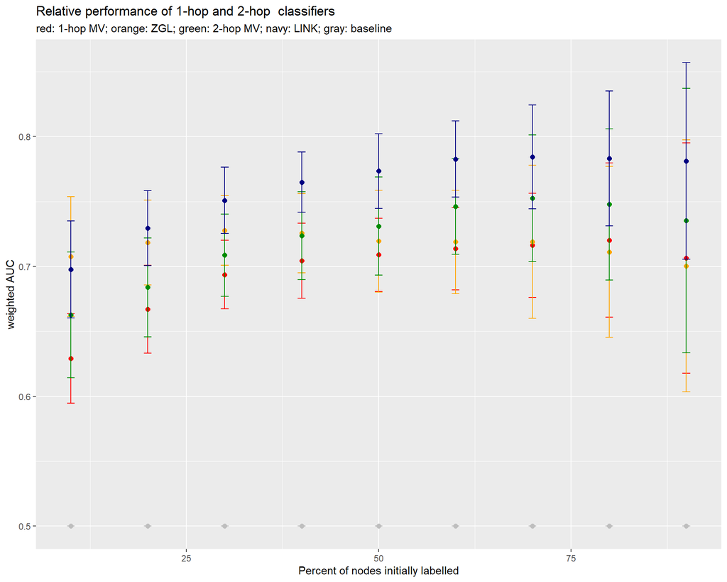

```r
df_wt_auc = data.frame(x = py$percent_initially_labelled,
                         baseline_mean = py$mean_wt_auc_baseline_net,
                         baseline_se = py$se_wt_auc_baseline_net,
                         mv_mean = py$mean_wt_auc_mv_net,
                         mv_se = py$se_wt_auc_mv_net,
                         zgl_mean = py$mean_wt_auc_zgl_net,
                         zgl_se = py$se_wt_auc_zgl_net,
                         mv2_mean = py$mean_wt_auc_mv2_net,
                         mv2_se = py$se_wt_auc_mv2_net,
                         link_mean = py$mean_wt_auc_link_net,
                         link_se = py$se_wt_auc_link_net)


p = ggplot(data = df_wt_auc, aes(x=x*100))+

  geom_point(aes(y=baseline_mean), color="gray", size=2)+
  geom_errorbar(aes(y=baseline_mean, ymin=baseline_mean-baseline_se, ymax=baseline_mean+baseline_se), color="gray", width=1)+

  geom_point(aes(y=mv_mean), color = "red", size=2)+
  geom_errorbar(aes(y=mv_mean, ymin=mv_mean-mv_se, ymax=mv_mean+mv_se),
                color="red", width=1)+

  geom_point(aes(y=zgl_mean), color="orange", size=2)+
  geom_errorbar(aes(y=zgl_mean, ymin=zgl_mean-zgl_se, ymax=zgl_mean+zgl_se),color="orange", width=1)+

  geom_point(aes(y=mv2_mean), color = "green4", size=2)+
  geom_errorbar(aes(y=mv2_mean, ymin=mv2_mean-mv2_se, ymax=mv2_mean+mv2_se),color="green4", width=1)+

  geom_point(aes(y=link_mean), color = "navy", size=2)+
  geom_errorbar(aes(y=link_mean, ymin=link_mean-link_se,
                    ymax=link_mean+link_se),
                color="navy", width=1)+

  labs(title = "Relative performance of 1-hop and 2-hop  classifiers",
      subtitle = "red: 1-hop MV; orange: ZGL; green: 2-hop MV; navy: LINK; gray: baseline",
       x = "Percent of nodes initially labelled",
       y = "weighted AUC")

p
```

## Discussion

This work reinforces Altenburger and Ugander’s assertion that monophily deserves special attention when studying social network preferences. From a practical perspective, monophily has proven to be crucial to inferring missing attributes in social networks. While researchers studying social network preferences have been predominantly focusing on in-class preference bias, Altenburger and Ugander highlighted the need to simultaneously consider variability. Future work could explore more complex networks (such as nodes with more than 3 classes) and possibly consider k-hop relations (k>2) in node classification methods.

> Appendix

### Homophily

The traditional homophily index of a graph (Coleman, 1958; Currarini et al., 2009) measures the aggregate pattern of individuals’ biases in forming friendships with people of their own attribute class relative to people from other classes. For an attribute class r, the homophily index $\widehat{h_r}$ with respect to class r is defined as:

$\widehat{h_r}=\frac{\sum_{i\in r}d_{i,in}}{\sum_{i\in r}d_{i,in}+\sum_{i\in r}d_{i,out}}=\frac{\sum_{i\in r}d_{i,in}}{\sum_{i\in r}d_i}$ (1)

where $d_i$ denotes node i’s observed total degree, $d_{i,in}$ denotes its in-class degree, and $d_{i,out}$ denotes its out-class degree. Further, we let $n_r$ represent the total number of nodes with attribute r, and let N denote the population: $N=\sum_{r=1}^{k}n_r$. We assume that each node forms in-class connections with the other $n_r$ nodes with probability $p_{in,r}$ and out-class ties with the other $n_s$ nodes with probability $p_out$. Thus, each node is expected to follow the following class-specific degree distributions:

$D_{i,in}|p_{in,r} \sim Binom(n_r,p_{in,r})$ (2)

$D_{i,out}|p_{out}\sim\ Binom(n_s,p_{out})$ (3)

$D_i|p_{in,r},p_{out}=D_{i,in}|p_{in,r}+D_{i,out}|p_{out}$ (4)

where $D_{i,in}$ is a random variable describing the in-class degree, $D_{i,out}$ describes the out-class degree and $D_i$ describes the total degree of node i in class r. Note that the random variables $D_{i,in}$ and $D_{i,out}$ in equations are approximately independent, but not completely: constraints on the joint distribution of the degrees create a dependence, but this dependence is small for graphs of modest size or larger and we safely ignore it here. Then, for node i in class r, its in-class degree distribution, conditional on its total observed degree, is approximately:

$D_{i,in}|{d_{i,}p}_{in,r,}p_{out}\sim\ Binom(d_{i,}\ n_rp_{in,r}/(n_rp_{in,r}+n_sp_{out})$ (5)

We denote the quantity $h_r = n_rp_{in,r}/(n_rp_{in,r}+n_sp_{out})$ in the above expression as the ‘homophily parameter’, as it characterizes the bias for nodes to connect with similar others. By applying a logistic regression model to the degree data, we can obtain the maximum likelihood estimation (MLE) of this parameter. The logistic link is $n_rp_{in,r}/(n_rp_{in,r}+n_sp_{out})=logit^{-1}(\beta_{0r})=e^{\beta_{0r}}/(1+e^{\beta_{0r}})$. Then, the MLE of

$\beta_{0r}$ is simply ${\hat{\beta}}_{0r}=\ logit(\sum_{i\in r}d_{i,in}/\sum_{i\in r}d_i)$ (6)

or equivalently ${\hat{\beta}}_{0r} = logit(\widehat{h_r})$. Thus we can see that the homophily index specified in equation (1) is precisely the MLE of the homophily parameter in the logistic regression model, and as a result, we can compute its statistical significance using the P value.

#### Simulation for homophily-only null distributions

I compared the variance of the empirical distribution of $d_{i,in}/d_i$ across all nodes in the same class with the variance of a binomial null distribution without overdispersion. To produce a distribution of samples under the null, I simulated draws from the distribution given in equation (5) by repeatedly sampling from $Binom(d_i, \widehat{h_r})$ for each node i in class r for 100000 iterations.

### Monophily

They modeled overdispersion using a quasi-likelihood method, which bears as few assumptions as possible compared with alternative methods for estimating overdispersion. This approach allows each node i in class r to have an individual latent preference for in-class connections, $h_{i,r}$, such that $\mathbb{E}\left[h_{i,r}\right]=h_r$ and $Var[h_{i,r}]=ϕ_rh_r(1 - h_r)$ for some $\phi_r \geq 0$. This approach could be regarded as loosely hierarchical, where $h_{i,r}$ is permitted to be random. When $\phi_r =0$, there is no excess variation. And $\phi_r >0$ captures variation beyond the conventional model. $\phi_r$ is estimated by an iterative procedure: first, a null model without overdispersion is assumed; the resulting residual variation is assessed via a goodness of fit statistic (chi-squared) based on the sum of squared residuals, and $\phi_{r}$ is updated until convergence. The final $\phi_{r}$ is the estimated overdispersion.

## References

Adamic, L. A., & Glance, N. (2005). The political blogosphere and the 2004 U.S. election: Divided they blog. Proceedings of the 3rd International Workshop on Link Discovery - LinkKDD ’05, 36–43.

Altenburger, K. M., & Ugander, J. (2018). Monophily in social networks introduces similarity among friends-of-friends. Nature Human Behaviour, 2(4), 284–290.

Coleman, J. (1958). Relational Analysis: The Study of Social Organizations with Survey Methods. Human Organization, 17(4), 28–36.

Currarini, S., Jackson, M. O., & Pin, P. (2007). An Economic Model of Friendship: Homophily, Minorities and Segregation. SSRN Electronic Journal.

Macskassy, S. A., & Provost, F. (2005). Classificaiton in Networked Data: A Toolkit and a Univariate Case Study: Defense Technical Information Center.

Resnick, M. D., Bearman, P. S., Blum, R. W., Bauman, K. E., Harris, K. M., Jones, J., Tabor, J., Beuhring, T., Sieving, R. E., Shew, M., Ireland, M., Bearinger, L. H., & Udry, J. R. (1997). Protecting adolescents from harm. Findings from the National Longitudinal Study on Adolescent Health. JAMA, 278(10), 823–832.

Traud, A. L., Mucha, P. J., & Porter, M. A. (2012). Social structure of Facebook networks. Physica A: Statistical Mechanics and Its Applications, 391(16), 4165–4180. Williams, L., Roberts, N., & Everton, S. (2019). Noordin Top Terrorist Network Data.

Zheleva, E., & Getoor, L. (2009). To join or not to join: The illusion of privacy in social networks with mixed public and private user profiles. Proceedings of the 18th International Conference on World Wide Web - WWW ’09, 531.

Zhu, X., Ghahramani, Z., & Lafferty, J. (2003). Semi-Supervised Learning Using Gaussian Fields and Harmonic Functions. Proc. 20th Int. Conf. Machine Learning 912–919